# Computational Part of Assessment Exercises

Advanced Statistical Inference - Unit 2

Alexander J Ohrt

29 november, 2021

## Problem 1

Modelling service times is one area of research in queuing theory. We are given a data set with service times for 174 customers. The distribution of service times is modelled using the one parameter Weibull distribution, which has the pdf

$$\begin{equation}
f(x) = \frac{2x}{\theta}e^{-x^2/\theta}I_{(0,\infty)}(x).
\end{equation}$$

### a)

A plot of the empirical cdf overimposed on the theoretical distribution function is shown below. The empirical cdf is plotted together with four different Weibull distribution functions. In all four cases, the shape parameter is fixed at 2. The scale parameters used in each case are the maximum likelihood estimator (MLE) for $\theta$, the method of moments estimator (MME) for $\theta$, a scale parameter found by a ‘maximum goodness-of-fit estimation’ and a scale parameter found by maximum likelihood estimation, both the latter scale parameters found with the function `fitdist`. Note that the MLE and the MME are calculated analytically in the latter parts of this exercise.

```r
data <- read.csv("Service.csv")
str(data)
head(data)
summary(data)
```

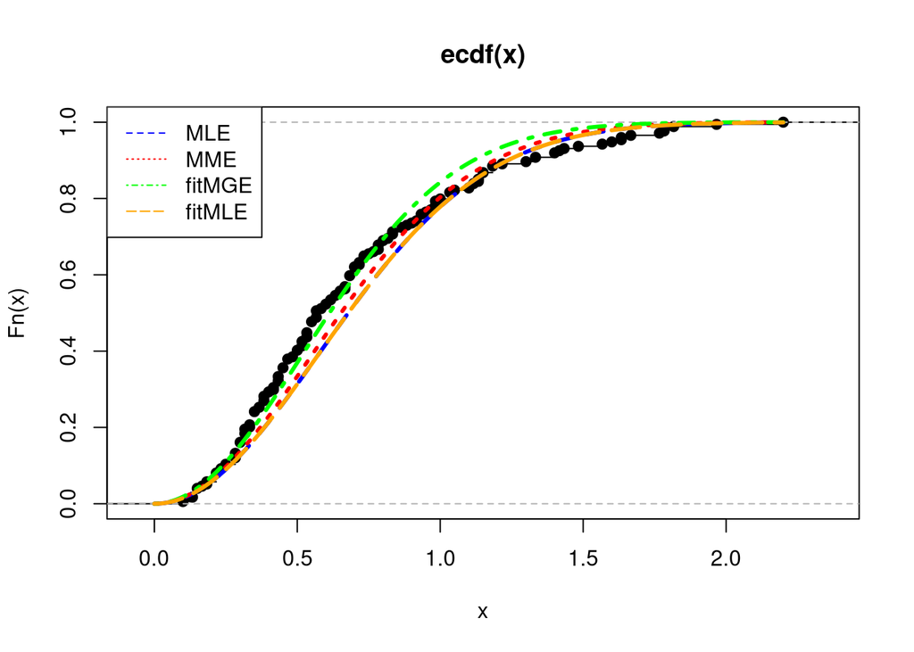

```r
x <- seq(0, max(data$Times), by = 0.001)
Emp.CDF <- ecdf(data$Times)
plot.ecdf(data$Times)
MLE <- mean(data$Times^2) # Estimator found later in problem.
MME <- 4*mean(data$Times)^2/pi # Estimator found later in problem.
lines(x, pweibull(x, shape = 2, scale = sqrt(MLE)), lty = 2, col = "blue", lwd = 3) # MLE estimator for theta.
lines(x, pweibull(x, shape = 2, scale = sqrt(MME)), lty = 3, col = "red", lwd = 3) # MOM-estimator for theta.

# Fix the shape parameter at 2 and only estimate the scale parameter.
fit.weibull.mge <- fitdist(data$Times, distr = "weibull", fix.arg = list("shape" = 2), method = "mge")
fit.weibull.mle <- fitdist(data$Times, distr = "weibull", fix.arg = list("shape" = 2), method = "mle")
lines(x, pweibull(x, shape = 2, scale = fit.weibull.mge$estimate[[1]]),
      lty = 4, col = "green", lwd = 3)
lines(x, pweibull(x, shape = 2, scale = fit.weibull.mle$estimate[[1]]),
      lty = 5, col = "orange", lwd = 3)
legend("topleft", legend = c("MLE", "MME", "fitMGE", "fitMLE"), lty = c(2,3,4,5), col = c("blue", "red", "green", "orange"))
```

Note that the ‘fitMLE’ and the ‘MLE’ graphs are overimposed, which shows that the analytically calculated maximum likelihood estimator (later in the problem) should be correct. Initially, without conducting any goodness-of-fit tests, the different theoretical distributions look to fit the data relatively well. Also note that there are ties in the data set, i.e. that several of the values appear several times, which does not make sense to be generated by a continuous distribution. This is because the probability of a random variable $X$ taking a value $c$ is zero in the continuous case, i.e. $P(X = c) = 0$.

### b)

A goodness-of-fit test is done to test whether the Weibull distribution is an adequate model for these data.

The Kolmogorov-Smirnov (KS) test is used for goodness-of-fit of each of the Weibull distribution functions found above. In the One-Sample KS test, which is used in this case, the null hypothesis states that the sample is drawn from the Weibull distribution. There are some problems with this methodology which I would like to point out. Firstly, we have the problem of ties in the data set, as already mentioned. This leads to some error in the calculations of the test-statistic and $p$-values. Secondly, the KS test does not give entirely correct results when the parameters of the theoretical distribution are estimated from the sample. The test statistic would need to be modified to correct for these mistakes. One possible solution, based on the bootstrap, can be found in a [paper](https://core.ac.uk/download/pdf/291565893.pdf) by Babu and Rao (2004). The `ks.test` function from the `dgof` library will be used to perform the test.

The Cramér-von Mises (CvM) test for goodness-of-fit is an alternative to the KS test. In the One-Sample version of the test, the null hypothesis is the same as in the KS test, that the data comes from the theoretical Weibull distribution. The `cvm.test` from the `goftest` library will be used to the perform the test. The function has an option where one can indicate whether or not the parameters are estimated from the sample, in order to adjust for the effect of this estimation. However, when this option is used, it assumes that both the parameters of the two-parameter Weibull are estimated, even though we only estimate one parameter in our case.

```r
(MLE.gof <- ks.test(data$Times, "pweibull", shape = 2, scale = sqrt(MLE)))
```

```
##
##  One-sample Kolmogorov-Smirnov test
##
## data:  data$Times
## D = 0.12221, p-value = 0.01107
## alternative hypothesis: two-sided
```

```r
(MME.gof <- ks.test(data$Times, "pweibull", shape = 2, scale = sqrt(MME)))
```

```
##
##  One-sample Kolmogorov-Smirnov test
##
## data:  data$Times
## D = 0.098937, p-value = 0.06632
## alternative hypothesis: two-sided
```

```r
set.seed(1)
(cvm.MLE <- cvm.test(data$Times, "pweibull", shape = 2, scale = sqrt(MLE), estimated = T))
```

```
##
##  Cramer-von Mises test of goodness-of-fit
##  Braun's adjustment using 13 groups
##  Null hypothesis: Weibull distribution
##  with parameters shape = 2, scale = 0.814724212763883
##  Parameters assumed to have been estimated from data
##
## data:  data$Times
## omega2max = 0.43903, p-value = 0.5243
```

```r
set.seed(1)
(cvm.MME <- cvm.test(data$Times, "pweibull", shape = 2, scale = sqrt(MME), estimated = T))
```

```
##
##  Cramer-von Mises test of goodness-of-fit
##  Braun's adjustment using 13 groups
##  Null hypothesis: Weibull distribution
##  with parameters shape = 2, scale = 0.784137055342378
##  Parameters assumed to have been estimated from data
##
## data:  data$Times
## omega2max = 0.38205, p-value = 0.6584
```

Choosing a significance level of 0.05 on the $p$-value of the tests, the One-Sample KS test would reject the null-hypothesis in the case where the MLE is used, but not in the case where MME is used. Thus, we can conclude that the Weibull with the scale parameter estimated with MLE is not a good fit, i.e. that the sample does not come from this distribution. On the other hand, we cannot conclude if the Weibull with the MME is a good fit, but it is not disregarded as a possibility at least, since the null-hypothesis is not rejected in this case.

The One-Sample CvM test does not reject any of the null hypotheses in this case, when adjusting for the estimation of the parameters from the sample.

The goodness-of-fit measures that are calculated when using the `fitdist`-function are given below.

```r
summary(fit.weibull.mge)
```

```
## Fitting of the distribution ' weibull ' by maximum goodness-of-fit
## Parameters :
##        estimate
## scale 0.7356447
## Fixed parameters:
##       value
## shape     2
## Loglikelihood:  -82.03879   AIC:  166.0776   BIC:  169.2366
```

```r
(ks.MGE <- ks.test(data$Times, "pweibull", shape = 2, scale = fit.weibull.mge$estimate[[1]]))
```

```
##
##  One-sample Kolmogorov-Smirnov test
##
## data:  data$Times
## D = 0.07257, p-value = 0.3187
## alternative hypothesis: two-sided
```

```r
set.seed(1)
(cvm.MGE <- cvm.test(data$Times, "pweibull", shape = 2, scale = fit.weibull.mge$estimate[[1]], estimated = T))
```

```
##
##  Cramer-von Mises test of goodness-of-fit
##  Braun's adjustment using 13 groups
##  Null hypothesis: Weibull distribution
##  with parameters shape = 2, scale = 0.735644656200929
##  Parameters assumed to have been estimated from data
##
## data:  data$Times
## omega2max = 0.39262, p-value = 0.6334
```

```r
summary(fit.weibull.mle)
```

```
## Fitting of the distribution ' weibull ' by maximum likelihood
## Parameters :
##        estimate Std. Error
## scale 0.8147233 0.03088175
## Fixed parameters:
##       value
## shape     2
## Loglikelihood:  -78.15084   AIC:  158.3017   BIC:  161.4607
```

```r
(ks.MLE <- ks.test(data$Times, "pweibull", shape = 2, scale = fit.weibull.mle$estimate[[1]])) # Same as above.
```

```
##
##  One-sample Kolmogorov-Smirnov test
##
## data:  data$Times
## D = 0.1222, p-value = 0.01107
## alternative hypothesis: two-sided
```

```r
set.seed(1)
(cvm.MLE <- cvm.test(data$Times, "pweibull", shape = 2, scale = fit.weibull.mle$estimate[[1]], estimated = T)) # Same as above.
```

```
##
##  Cramer-von Mises test of goodness-of-fit
##  Braun's adjustment using 13 groups
##  Null hypothesis: Weibull distribution
##  with parameters shape = 2, scale = 0.814723330906493
##  Parameters assumed to have been estimated from data
##
## data:  data$Times
## omega2max = 0.43903, p-value = 0.5243
```

The rest of the problem has been typeset in the other pdf.

## Problem 2

Two researchers collected data on the price of hardcover textbooks from two disciplinary areas: Mathematics and the Natural Sciences and the Social Sciences.

```r
books <- read.csv("bookprices.csv")
head(books)
str(books)
summary(books)
books$areaFact <- as.factor(books$Area)
```

### a)

Some exploratory data analysis on book prices for each of the two areas is done.

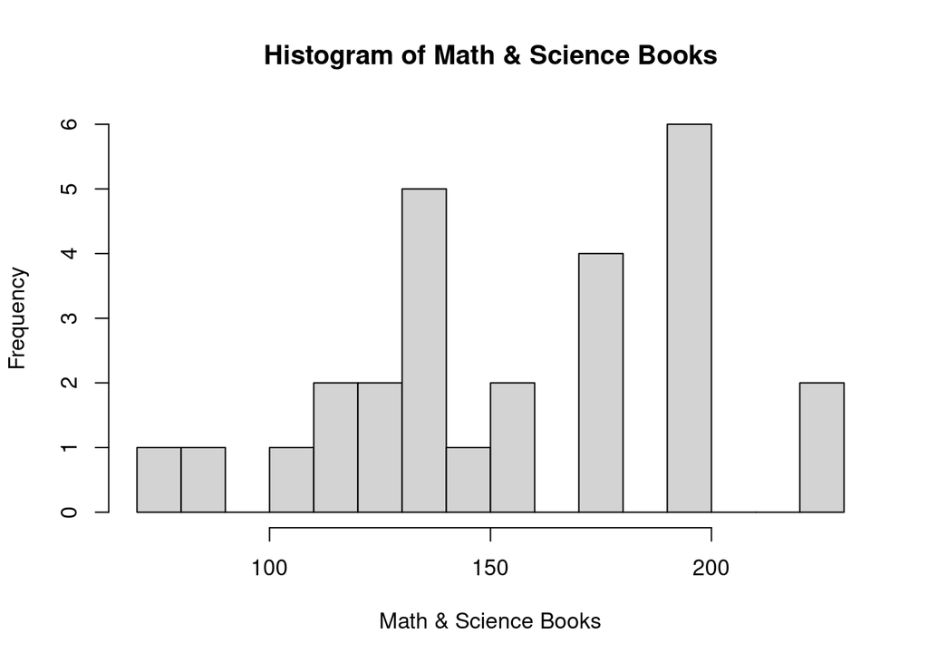

```r
only.Math <- books[books$Area == "Math & Science", "Price"] # Only Math book prices.
s.math <- summary(only.Math)
hist(only.Math, breaks = 20, xlab = "Math & Science Books", main = "Histogram of Math & Science Books")
```

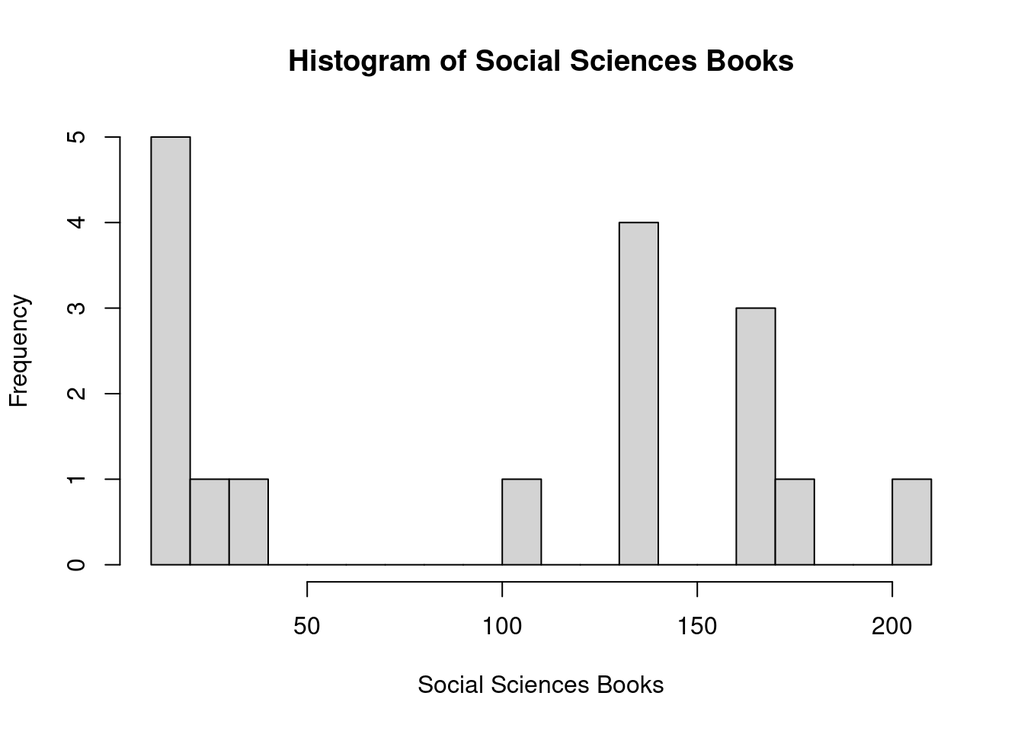

```r
only.Social <- books[books$Area == "Social Sciences", "Price"] # Only Social book prices.
s.soc <- summary(only.Social)
hist(only.Social, breaks = 20, xlab = "Social Sciences Books", main = "Histogram of Social Sciences Books")
```

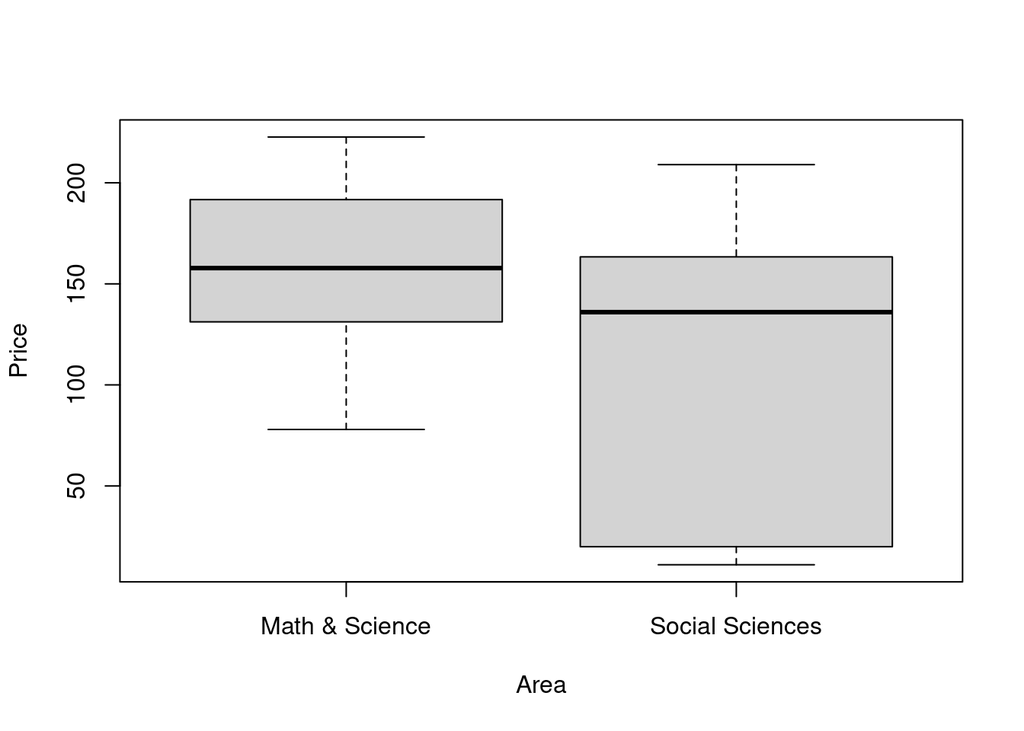

```r
boxplot(Price ~ Area, data = books)
```

```r
df <- cbind(s.math, s.soc)
colnames(df) <- c("Math & Science", "Social Sciences")
df <- rbind(df, "Std. Err." = c(sd(only.Math), sd(only.Social)), "Sum" = c(sum(only.Math), sum(only.Social)),
            "Books" = c(as.integer(length(only.Math)), as.integer(length(only.Social))))
df
```

```
##           Math & Science Social Sciences
## Min.            77.95000        11.00000
## 1st Qu.        131.20000        19.95000
## Median         157.80000       136.00000
## Mean           156.73407        98.99000
## 3rd Qu.        191.70000       163.35000
## Max.           222.67000       209.00000
## Std. Err.       39.14483        71.91385
## Sum           4231.82000      1682.83000
## Books           27.00000        17.00000
```

At first glance at the summary above, the price in the two areas look quite different. This might suggest that there is a difference in prices in general between the two areas. All the quantiles are lower in the Social Sciences compared to the respective quantiles in Math & Science, which might suggest that prices on many books are lower in the former area compared to the latter area. Note that there are a different amount of books from each area in the data set and that the total sum of prices is different.

### b)

A Bootstrap for the mean of book prices in each area is done below.

```r
B <- 10000
b.means.Math <- rep(NA, B)
set.seed(1)
for (i in 1:B){
  b.means.Math[i] <- mean(sample(only.Math, replace = T))
}

boot.mean.Math <- mean(b.means.Math)
boot.sd.Math <- sd(b.means.Math)

rbind("Estimation of Bootstrap Mean" = boot.mean.Math, "Estimation of Bootstrap Std. Err" = boot.sd.Math)
```

```
##                                        [,1]
## Estimation of Bootstrap Mean     156.798175
## Estimation of Bootstrap Std. Err   7.332685
```

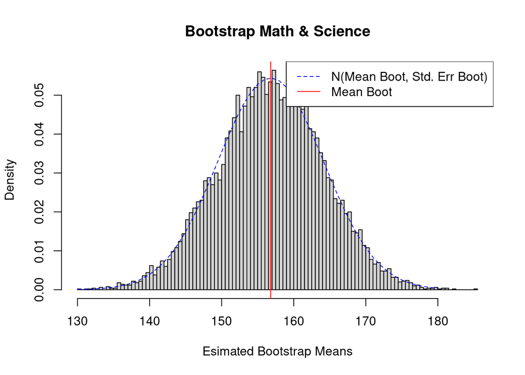

```r
hist(b.means.Math, breaks = 100, probability = T, main = "Bootstrap Math & Science", xlab = "Esimated Bootstrap Means")
x <- seq(130, 180, by = 1)
lines(x, dnorm(x, mean = boot.mean.Math, sd = boot.sd.Math), col = "blue", lty = 2)
abline(v = boot.mean.Math, col = "red", lty = 1)
legend("topright", legend = c("N(Mean Boot, Std. Err Boot)", "Mean Boot"), col = c("blue", "red"), lty = 2:1)
```

A normal distribution function with the estimated bootstrap mean and standard error is added to the histogram above. Thus, we can see that the distribution of the bootstrap means resembles this normal distribution.

```r
b.means.Social <- rep(NA, B)
set.seed(1)
for (i in 1:B){
  b.means.Social[i] <- mean(sample(only.Social, replace = T))
}
boot.mean.Social <- mean(b.means.Social)
boot.sd.Social <- sd(b.means.Social)

rbind("Estimation of Bootstrap Mean" = boot.mean.Social, "Estimation of Bootstrap Std. Err" = boot.sd.Social)
```

```
##                                      [,1]
## Estimation of Bootstrap Mean     99.08294
## Estimation of Bootstrap Std. Err 16.87686
```

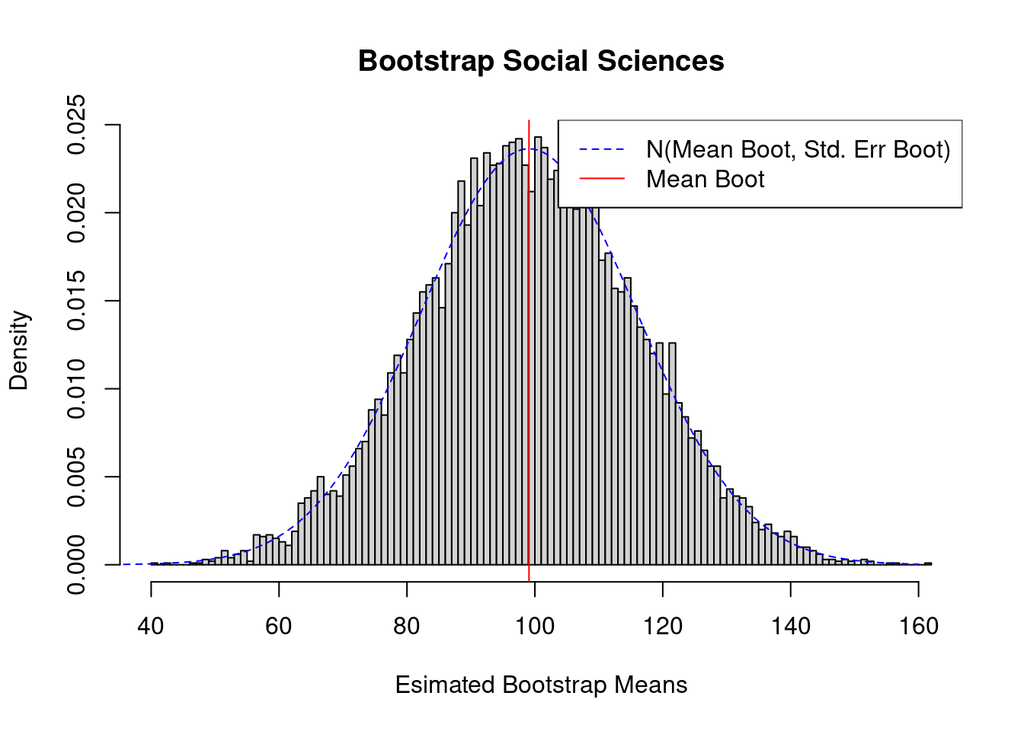

```r
hist(b.means.Social, breaks = 100, probability = T, main = "Bootstrap Social Sciences", xlab = "Esimated Bootstrap Means")
x <- seq(30, 160, by = 1)
lines(x, dnorm(x, mean = boot.mean.Social, sd = boot.sd.Social), col = "blue", lty = 2)
abline(v = boot.mean.Social, col = "red", lty = 1)
legend("topright", legend = c("N(Mean Boot, Std. Err Boot)", "Mean Boot"), col = c("blue", "red"), lty = 2:1)
```

Similarly to the case of Math & Science, a normal distribution function with the estimated bootstrap mean and standard error is added to the histogram above. Thus, we can see that the distribution of the bootstrap means resembles this normal distribution.

A summary of the bootstrapped means is given below. Also, the summary from a) is plotted again.

```r
df.means <- cbind("Math & Science" = boot.mean.Math, "Social Sciences" = boot.mean.Social)
rownames(df.means) <- "Bootstrap Means"
df.means
```

```
##                 Math & Science Social Sciences
## Bootstrap Means       156.7982        99.08294
```

```r
df
```

```
##           Math & Science Social Sciences
## Min.            77.95000        11.00000
## 1st Qu.        131.20000        19.95000
## Median         157.80000       136.00000
## Mean           156.73407        98.99000
## 3rd Qu.        191.70000       163.35000
## Max.           222.67000       209.00000
## Std. Err.       39.14483        71.91385
## Sum           4231.82000      1682.83000
## Books           27.00000        17.00000
```

It is apparent that the sample means are relatively similar to the estimations of the bootstrap means.

Below, the bootstrap has been done using the library `boot`, which gives the same results as when done manually.

```r
mean.func <- function(data, i){
  return(mean(data[i]))
}
set.seed(1)
bm2 <- boot::boot(only.Math, mean.func, R = B)
bm2
```

```
##
## ORDINARY NONPARAMETRIC BOOTSTRAP
##
##
## Call:
## boot::boot(data = only.Math, statistic = mean.func, R = B)
##
##
## Bootstrap Statistics :
##     original     bias    std. error
## t1* 156.7341 0.06410063    7.381964
```

```r
mean(bm2$t)
```

```
## [1] 156.7982
```

```r
set.seed(1)
bs2 <- boot::boot(only.Social, mean.func, R = B)
bs2
```

```
##
## ORDINARY NONPARAMETRIC BOOTSTRAP
##
##
## Call:
## boot::boot(data = only.Social, statistic = mean.func, R = B)
##
##
## Bootstrap Statistics :
##     original     bias    std. error
## t1*    98.99 0.09293776    16.81281
```

```r
mean(bs2$t)
```

```
## [1] 99.08294
```

### c)

The ratio of means is bootstrapped in this problem and an estimate of the standard error of the ratio is provided.

```r
B <- 5000
b.ratio.means <- rep(NA, B)
set.seed(1)
for (i in 1:B){
  Math.resample <- sample(only.Math, replace = T)
  Social.resample <- sample(only.Social, replace = T)
  mean.math <- mean(Math.resample)
  mean.social <- mean(Social.resample)
  b.ratio.means[i] <- mean.math/mean.social
}
boot.ratio.mean <- mean(b.ratio.means)
boot.ratio.sd <- sd(b.ratio.means)

rbind("Estimation of Bootstrap Ratio of Means" = boot.ratio.mean, "Estimation of Bootstrap Std. Err of Ratio" = boot.ratio.sd)
```

```
##                                                [,1]
## Estimation of Bootstrap Ratio of Means    1.6314933
## Estimation of Bootstrap Std. Err of Ratio 0.3216363
```

Below, the estimated bootstrap ratio of means is found with the library `boot`. The variances of each of the bootstrap estimation are also estimated, using the bootstrap, such that they can be used to calculate “studentized” confidence intervals in problem d). More specifically, the are found by bootstrapping each resample in the ‘outer’ bootstrap. Thus we have two levels of bootstrapping: one that resamples from the original sample (to estimate the ratio of means) and one that resamples from each resample (to estimate the variance of each bootstrap estimation). The results are probably different from the results obtained above because of differences in seeds used when sampling in each iteration.

```r
N <- 500 # Iterations for Bootstrap estimate of variance.
new.book.data <- cbind(c(only.Math, only.Social), c(rep(1,times=27), rep(2, times = 17)))
colnames(new.book.data) <- c("Price", "Area")

theta2 <- function(data, i){
  area <- data[i, 2]
  price <- data[i, 1]
  return(mean(price[area==1])/mean(price[area==2]))
}

theta3 <- function(data, i){
  area <- data[i, 2]
  price <- data[i, 1]
  b <- boot::boot(data[i,], theta2, R = N, strata = data[i,2])
  #b <- boot::boot(data, theta2, R = N, strata = data[,2])
  c(mean(price[area==1])/mean(price[area==2]), var(b$t))
}

set.seed(1)
(b <- boot::boot(new.book.data, theta3, R = B, strata = new.book.data[,2]))
```

```
##
## STRATIFIED BOOTSTRAP
##
##
## Call:
## boot::boot(data = new.book.data, statistic = theta3, R = B, strata = new.book.data[,
##     2])
##
##
## Bootstrap Statistics :
##      original     bias    std. error
## t1* 1.5833324 0.04771011   0.3115303
## t2* 0.1104409 0.03015846   0.1395659
```

The estimated bootstrap ratio of means using the library is

```r
mean(b$t[,1])
```

```
## [1] 1.631043
```

### d)

95% confidence intervals for the ratio of means are found using the “percentile” and the “studentized” method.

A confidence interval with the “percentile” method is given below. The first interval is the confidence interval for the results when using my manual bootstrap above, and the second interval is the confidence interval calculated with the bootstrap using the library `boot`.

```r
sample.ratio <- mean(only.Math)/mean(only.Social) # Ratio of means in sample.
(ciPercentile <- quantile(b.ratio.means, c(0.025, 0.975))) # Quantile/percentile with manual bootstrap.
```

```
##     2.5%    97.5%
## 1.164954 2.397364
```

```r
quantile(b$t[,1], c(0.025, 0.975)) # Quantile/percentile with boot library.
```

```
##     2.5%    97.5%
## 1.170979 2.382805
```

A confidence interval with the “studentized” method is given below.

```r
z <- rep(NA, B)
set.seed(1)
for (i in 1:B){
  Math.resample <- sample(only.Math, replace = T)
  Social.resample <- sample(only.Social, replace = T)
  mean.math <- mean(Math.resample)
  mean.social <- mean(Social.resample)
  b.ratio.means[i] <- mean.math/mean.social
  new.d <- cbind(c(Math.resample, Social.resample), c(rep(1,times=27), rep(2, times = 17)))
  # Manual bootstrap to estimate the standard error of each bootstrap estimate of the ratio.
  se.resample <- rep(NA, N)
  for (j in 1:N){
    se.resample[j] <- mean(sample(Math.resample, replace = T))/mean(sample(Social.resample, replace = T))
  }

  # Bootstrap via library to estimate the standard error of each bootstrap estimate of the ratio.
  #boot.se <- boot::boot(new.d, theta2, R = 1000, strata = new.d[, 2])

  # Choice below depends on manual bootstrap or not.
  #z[i] <- (b.ratio.means[i]-sample.ratio)/sd(boot.se$t)
  z[i] <- (b.ratio.means[i]-sample.ratio)/sd(se.resample)
}

#(ciStudentized <- c(sample.ratio - quantile(z, 0.975)*boot.ratio.sd, sample.ratio - quantile(z, 0.025)*boot.ratio.sd))
(sample.ratio + boot.ratio.sd*quantile(-z, c(0.025, 0.975))) # The same.
```

```
##     2.5%    97.5%
## 1.200419 2.433073
```

```r
boot.ci(b, type = c("stud", "perc"))
```

```
## BOOTSTRAP CONFIDENCE INTERVAL CALCULATIONS
## Based on 5000 bootstrap replicates
##
## CALL :
## boot.ci(boot.out = b, type = c("stud", "perc"))
##
## Intervals :
## Level    Studentized          Percentile
## 95%   ( 1.192,  2.477 )   ( 1.171,  2.383 )
## Calculations and Intervals on Original Scale
```

The last output shows the confidence intervals using the `boot.ci` function from the library `boot`. The results when using the library compared to when bootstrapping manually are still a bit different.

### e)

A permutation test to compare the two bootstrap means is built in this problem. It is applied to the data and the result is compared with an alternative based on a non-parametric test. First, the difference of bootstrap means is found, which is shown below.

```r
(diff.boot.means <- boot.mean.Math - boot.mean.Social) # First find the difference of means.
```

```
## [1] 57.71524
```

In this case, the null hypothesis is that the mean in the two groups are equal. Then, the constructed permutation test is applied to the data.

```r
perms <- 10000
diffs <- rep(NA, perms)
set.seed(1)
for (i in 1:perms){
  s <- sample(books[, "Price"]) # Sample from the combined population.
  diffs[i] <- mean(s[1:27]) - mean(s[28:44]) # Keep 27 in Math and 17 in Social.
}
```

The histogram shows the distribution of the different permutation resamples. Moreover, the positive difference of means and the negative difference of means are plotted in dashed red lines.

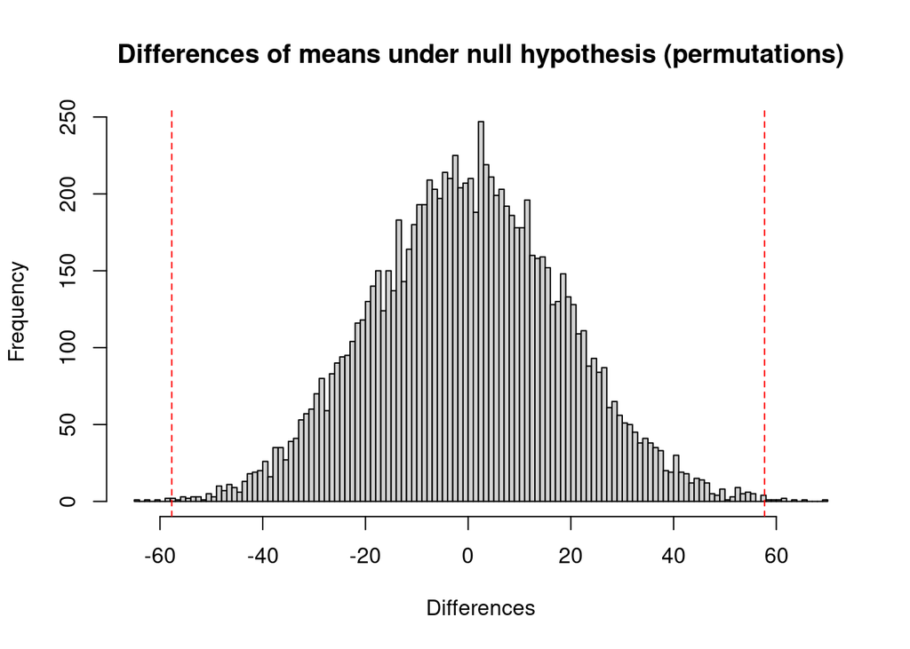

```r
# The null hypothesis looks to not hold that well.
hist(diffs, breaks = 100, main = "Differences of means under null hypothesis (permutations)",
     xlab = "Differences")
abline(v=c(-diff.boot.means, diff.boot.means), col = "red", lty = 2)
```

The $p$-value is found by counting the amount of differences in means found under the null hypothesis, via permutation, that are larger than the positive difference of means or smaller than the negative difference of means. We are using a two-sided test since we want to test the difference between the means in both directions, even though we suspect that the mean in Math & Science is larger than the mean in Social Sciences.

```r
# Calculate the p-value. Evidence against null hypothesis I would say, which means that the ratios are different.
(p_value <- (sum(diffs >= diff.boot.means) + sum(diffs <= -diff.boot.means))/perms)
```

```
## [1] 0.0016
```

As can be seen from the $p$-value above, it is statistically significant to any reasonable level, which means that the null hypothesis can be rejected. We conclude that there exists a difference in the means, based on the two-sided test.

Next, we should compare this result to an alternative based on a non-parametric test. A test based on the bootstrap is considered. This is very similar to the permutation test, except that the sampling is with replacement, instead of without replacement. The counted $p$-value is shown below.

```r
B <- 10000
diffs <- rep(NA, B)
set.seed(1)
for (i in 1:B){
  s <- sample(books[, "Price"], replace = T) # Sample from the combined population.
  diffs[i] <- mean(s[1:27]) - mean(s[28:44]) # Keep 27 in Math and 17 in Social.
}

((sum(diffs >= diff.boot.means) + sum(diffs <= -diff.boot.means))/B)
```

```
## [1] 0.0015
```

This gives the same conclusion, that the means are statistically different.

### f)

Are the answers to the previous questions consistent? The tests done in e) indicate that the means of the two areas are statistically different. The estimate of the bootstrap ratio of the means also indicates the same, since the ratio is estimated to 1.6314933 and the standard error of this estimate is estimated to 0.3216363. Additionally, the confidence intervals built from the bootstrap estimates give rise to the same conclusion. This is seen from the confidence intervals, since they do not contain the value 1 (with 95% confidence), which means that the ratio of means is statistically different from 1. Thus, I would conclude that all answers in this problem are consistent; that the mean price in Math & Science is larger than the mean price in Social Sciences.